# act_report

### The Act Report

#### Questions

```
- Is the rating given to the dog related to the times the image was favorited?
- Is the rating given to the dog related to the times the image was retweeted?
- Is the rating given to the dog related with the confidence in prediction by the algorithm?
```

```python
import pandas as pd
import matplotlib.pyplot as plt
```

```python
df = pd.read_csv('twitter_archive_master.csv')
df.head()
```

|  | tweet_id | in_reply_to_status_id | in_reply_to_user_id | timestamp | source | text | expanded_urls | rating_numerator | rating_denominator | name | ... | p1_conf | p1_dog | p2 | p2_conf | p2_dog | p3 | p3_conf | p3_dog | retweet_count | favorite_count |
| --- | --- | --- | --- | --- | --- | --- | --- | --- | --- | --- | --- | --- | --- | --- | --- | --- | --- | --- | --- | --- | --- |
| 0 | 892420643555336193 | NaN | NaN | 2017-08-01 16:23:56+00:00 | Twitter for iPhone | This is Phineas. He's a mystical boy. Only eve... | https://twitter.com/dog_rates/status/892420643... | 13 | 10 | Phineas | ... | 0.097049 | False | Orange | 0.085851 | False | Orange | 0.076110 | False | 7733 | 36346 |
| 1 | 892177421306343426 | NaN | NaN | 2017-08-01 00:17:27+00:00 | Twitter for iPhone | This is Tilly. She's just checking pup on you.... | https://twitter.com/dog_rates/status/892177421... | 13 | 10 | Tilly | ... | 0.323581 | True | Chihuahua | 0.090647 | True | Chihuahua | 0.068957 | True | 5727 | 31311 |
| 2 | 891815181378084864 | NaN | NaN | 2017-07-31 00:18:03+00:00 | Twitter for iPhone | This is Archie. He is a rare Norwegian Pouncin... | https://twitter.com/dog_rates/status/891815181... | 12 | 10 | Archie | ... | 0.716012 | True | Chihuahua | 0.078253 | True | Chihuahua | 0.031379 | True | 3789 | 23592 |
| 3 | 891689557279858688 | NaN | NaN | 2017-07-30 15:58:51+00:00 | Twitter for iPhone | This is Darla. She commenced a snooze mid meal... | https://twitter.com/dog_rates/status/891689557... | 13 | 10 | Darla | ... | 0.170278 | False | Paper towel | 0.168086 | True | Paper towel | 0.040836 | False | 7901 | 39660 |
| 4 | 891327558926688256 | NaN | NaN | 2017-07-29 16:00:24+00:00 | Twitter for iPhone | This is Franklin. He would like you to stop ca... | https://twitter.com/dog_rates/status/891327558... | 12 | 10 | Franklin | ... | 0.555712 | True | Basset | 0.225770 | True | Basset | 0.175219 | True | 8520 | 37832 |

5 rows × 24 columns

##### Is the rating given to the dog related to the times the image was favorited?

> Because of the left-skewed distribution of rating numerator, when analyzing the correlation between it and the favorite count we have to keep in mind that the percentage of dogs with a rating equal or higher than 10 is greater than dogs with a rating lower than 10. From the scatter plot, we can assure there is a correlation between the rating and how many times the tweet was favorited. From rating 10 on, we can verify that the favorite count is growing. Below the 10 rating numerator mark, only a few outsiders have a favorite count higher than 40.000 favorited tweets. So the conclusion is YES, the rating given to the dog is related to the number of times the image was favorited.

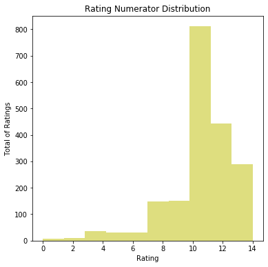

```python
# Verify how the rating numerators are distributed

def graph():
    plt.hist(df['rating_numerator'], alpha=0.5, facecolor='y')

plt.figure(figsize=[6,6])
plt.title('Rating Numerator Distribution')
plt.ylabel('Total of Ratings')
plt.xlabel('Rating')

plt.show(graph());
```

Rating numerators distribution is skewed to the left.

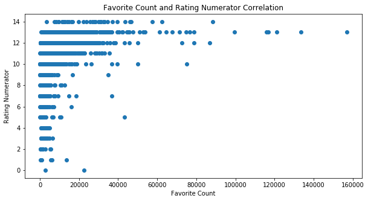

```python
# Favorite count and rating

fc = df['favorite_count']
rn = df['rating_numerator']

plt.figure(figsize=[10,5])
plt.grid(False)
plt.title('Favorite Count and Rating Numerator Correlation')
plt.ylabel('Rating Numerator')
plt.xlabel('Favorite Count')

plt.scatter(fc,rn);
```

##### Is the rating given to the dog related to the times the image was retweeted?

> By analyzing the scatter plot of the correlation between the retweeted count and the rating of each dog, we can assume that there is a positive correlation. Keeping in mind the left-skewed distribution of rating numerator, we can see that below the 10 rating numerator mark there are only two observations with more than 10.000 retweets. For dogs with a rating equal to or higher than 10, there is a higher probability of getting more retweets.

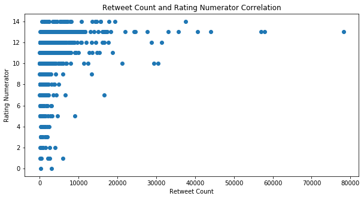

```python
# Retweeted count and rating

rc = df['retweet_count']
rn = df['rating_numerator']

plt.figure(figsize=[10,5])
plt.grid(False)
plt.title('Retweet Count and Rating Numerator Correlation')
plt.ylabel('Rating Numerator')
plt.xlabel('Retweet Count')

plt.scatter(rc,rn);
```

##### Is the rating given to the dog related with the confidence in prediction by the algorithm?

> From the scatter plot, we can assume that there is no correlation between the algorithm's first prediction confidence and the rating given to the dog. There are highly rated dogs with lower confidence prediction as well as low rated dogs with higher prediction confidence. As mentioned before, we need to be aware of the left-skewed distribution of ratings to explain the number of observations at the top of the scatter plot.

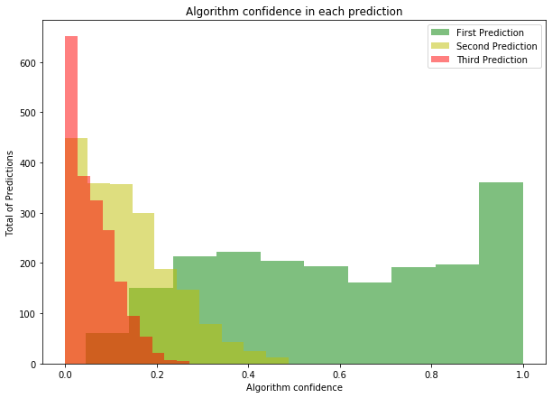

```python
def graph():
    plt.hist(df['p1_conf'], facecolor='g', alpha=0.5, label='First Prediction')
    plt.hist(df['p2_conf'], facecolor='y', alpha=0.5, label='Second Prediction')
    plt.hist(df['p3_conf'], facecolor='r', alpha=0.5, label='Third Prediction')
    plt.legend(loc='upper right')

plt.figure(figsize=[10,7])
plt.title('Algorithm confidence in each prediction')
plt.ylabel('Total of Predictions')
plt.xlabel('Algorithm confidence')

plt.show(graph());
```

From the distribution of each prediction confidence made by the algorithm, we can verify that the chances of a higher confidence prediction rely on the first prediction. Both second and third predictions have lower than .5 confidence levels. The first prediction has a larger range, varying from almost zero to one. Because of that, we will use the first prediction to compare to the rating given.

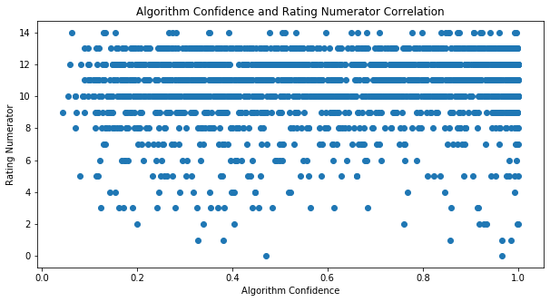

```python
# Retweeted count and rating

pc = df['p1_conf']
rn = df['rating_numerator']

plt.figure(figsize=[10,5])
plt.grid(False)
plt.title('Algorithm Confidence and Rating Numerator Correlation')
plt.ylabel('Rating Numerator')
plt.xlabel('Algorithm Confidence')

plt.scatter(pc,rn);
```